# Biblioteka rozkładów

Rozkłady do tworzenia symulacji

Weronika Mucha, Aleksandra Duda

# Wprowadzenie

Dokument powstał w celu uporządkowania wiedzy dotyczącej rozkładów przydatnych w procesie tworzenia symulacji. Rozkłady zostały opisane na podstawie stworzonych historycznych symulacji, kompendium sprzężonych rozkładów apriorycznych (Fink 1997) oraz powszechnie dostępnych źródeł dodanych w bibliografii.

## Etapy tworzenia symulacji

Konstrukcję symulacji rozpoczynamy od ustalenia parametrów potrzebnych do rozpatrywania mocy pierwszorzędowego punktu końcowego oraz liczby iteracji.

- Etap 1: Dla każdego parametru określamy rozkład, z którego pochodzi i podstawowe wartości takie jak średnia, odchylenie standardowe oraz parametry dla poszczególnych rozkładów np. dla rozkładu beta: alfa i beta (parametry kształtu), dla rozkładu Dirichleta: parametry skupienia wektorów alfa. Warto wylosować przykładową wartość dla każdego parametru. W taki sposób otrzymujemy ramkę danych dla wybranych wielkości próby powtórzonych zgodnie z liczbą iteracji. Parametry wskazują na wartości i prawdopodobieństwa przyjęte dla każdej kolejnej symulacji.
- Etap 2 Następny etap polega na stworzeniu ramki wyników dla każdej kolejnej symulacji z odpowiednimi parametrami, czyli np. gdy dla 1 symulacji wylosowaliśmy wielkość próby równą 25, a przyjęta wcześniej liczba iteracji wynosi 100, to ramka danych wyników dla 1 symulacji ma wygenerowanych 100 pacjentów z odpowiednimi wartościami parametrów zgodnie z prawdopodobieństwami z ramki parametrów.

Możemy wykonać ramkę zbiorczą z numerem symulacji, wygenerowaną ramką parametrów i odpowiednią dla niej otrzymaną ramką wyników.

## Metodyka

Dla Etapu 1 tworzymy ramki danych, wpisując odpowiednie informacje uzyskane z literatury oraz od badaczy. Możemy podzielić parametry ze względu na wybrany do estymacji rozkład i stworzyć mniejsze ramki danych później łącząc je w całość prawdopodobieństw dla wszystkich parametrów.

W Etapie 2 generujemy ramkę wyników korzystając funkcji defDataAdd z pakietu simstudy (Keith Goldfeld, n.d.), która dodaje kolejne zmienne do utworzonej już tabeli: Argumenty w funkcji:

- dtDefs- tabela, do której chcemy dodać kolejne wartości
- varname- nazwa zmiennej
- formula- może być określony jako konkretna liczba (średnia) lub opisana wzorem odwołującym się do innej zmiennej
- variance- wartość wariancji
- dist- rozkład do generowania danych

Argument “distribution”:

- “nonrandom”- rozkład spoza listy dostępnej w pakiecie, możemy w tej sytuacji napisać własną funkcję do generowania danych z dowolnego rozkładu, wtedy w argumencie formula podajemy nazwę funkcji w cudzysłowie.
- możemy podać nazwę rozkładu, z którego chcemy generować

## Przykład generowania danych

```r
def <- defData(varname = "age", dist = "normal", formula = 10,
    variance = 2)
def <- defData(def, varname = "female", dist = "binary",
    formula = "-2 + age * 0.1", link = "logit")
def <- defData(def, varname = "visits", dist = "poisson",
    formula = "1.5 - 0.2 * age + 0.5 * female", link = "log")
```

W przykładzie generujemy zmienną wiek, określając średnią jako 10, zmienna kobieta zależna jest od wieku, a wzór na nią został zaimplementowany w argumencie “formula”, podobnie ze zmienną wizyty.

```r
myinv <- function(x) {
    1/x
}

def <- defData(varname = "age", formula = 10, variance = 2,
    dist = "normal")
def <- defData(def, varname = "loginvage", formula = "log(myinv(age))",
    variance = 0.1, dist = "normal")
```

W przykładzie zostało zaprezentowane generowanie zmiennych z argumentem “formula” opisanym za pomocą dodanej wcześniej funkcji.

| number | name | formula | distribution |
| --- | --- | --- | --- |
| 1 | beta | mean | continuous |
| 2 | binary | probability | discrete |
| 3 | binomial | probability | discrete |
| 4 | categorical | probability | discrete |
| 5 | exponential | mean | continuous |
| 6 | gamma | mean | continuous |
| 7 | mixture | formula | - |
| 8 | negBinomial | mean | discrete |
| 9 | nonrandom | formula | - |
| 10 | normal | mean | continuous |
| 11 | noZeroPoisson | mean | discrete |
| 12 | poisson | mean | discrete |
| 13 | trtAssign | ratio | - |
| 14 | uniform | range | continous |
| 15 | uniformlnt | range | discrete |

Poniżej zostały opisane rozkłady w podziale na dyskretne i ciągłe, które możliwe są do zastosowania w bibliotece simstudy.

# Rozkłady dyskretne z pakietu simstudy

## Rozkład Bernoulliego/dwumianowy (binomial distribution)

### Rozkład do niego sprzężony: Beta

### Opis rozkładu

Rozkład opisujący liczbę sukcesów $k$ w ciągu $N$ niezależnych prób, z których każda ma stałe prawdopodobieństwo sukcesu równe $p$. Rozkładem, który opisuje liczbę sukcesów w ciągu N prób, jest rozkład hipergeometryczny (próby są zależne).

Parametry:

- $n$- liczba prób
- $p$- prawdopodobieństwo sukcesu

Funkcja rozkładu prawdopodobieństwa:
$$X\sim\text{B}(n,p)$$

$$f(x;n,p)={n\choose
k}p^{k}(1-p)^{n-k}$$
$$\text{E(X)}=np
\qquad \text{Var}(X)=np(1-p)$$

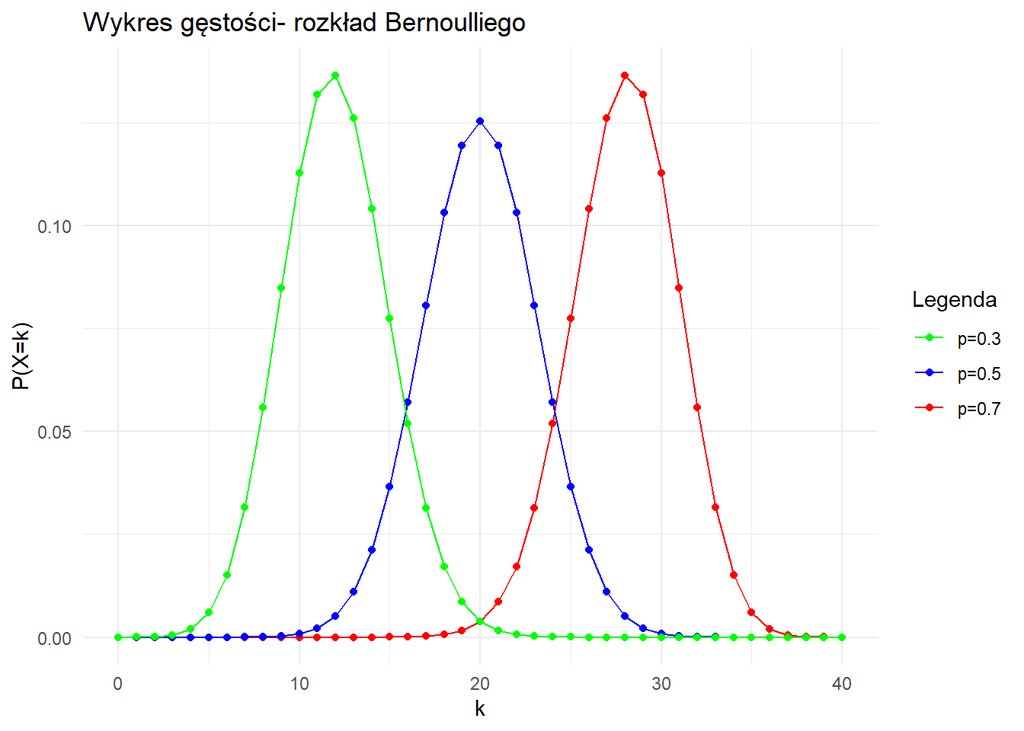

### Zastosowanie w medycynie

- Stosowany wszędzie tam, gdzie mamy 2 możliwości sukces lub porażkę np. przyjęcia leku, działania tabletek itp..
- Możemy używać do określenia typu choroby lub przynależności do danej grupy, np. kohorta i typ mistenii gravis w dokumencie UM Lublin.

## Rozkład zero-jedynkowy (binary distribution)

### Rozkład do niego sprzężony: Beta

### Opis rozkładu

Jest to szczególny przypadek rozkładu dwupunktowego, gdzie zmienna losowa przyjmuje tylko wartości 0 i 1. Używamy do określenia prawdopodobieństwa pojedynczego zdarzenia.

$$\text{E(X)}=p \qquad
\text{Var}(X)=p(1-p)$$

## Rozkład kategoryczny

### Rozkład do niego sprzężony: Dirichlet

### Opis rozkładu

Jest nazywany uogólnionym rozkładem Bernoulliego, mamy więcej niż 2 możliwe kategorie. Rozkład przyjmuje wartości od 1 do K, każda wartość reprezentuje inną kategorię, a kategorii jest K. Dla zmiennej kategorycznej z k kategoriami, wzór jest ciągiem prawdopodobieństw, które sumują się do 1.

## Rozkład ujemny dwumianowy (Rozkład Pascala)

### Rozkład do niego sprzężony: Beta

Rozkład opisuje liczbę sukcesów i porażek w niezależnych i posiadających równe prawdopodobieństwo sukcesu próbach Bernoulliego, zanim pojawi się określona liczba sukcesów. Jest uogólnieniem rozkładu geometrycznego dla wielu prób.

Parametry:

- $r$- liczba sukcesów do zakończenia eksperymentu
- $p$- prawdopodobieństwo sukcesu

### Zastosowanie w medycynie

- Może być stosowany do określenia wielkości próby w badaniu, gdzie oczekujemy efektu przy danej liczbie osób (DeVeaux, Kane, and Zelterman 2015).

## Rozkład Poissona

### Rozkład do niego sprzężony: Gamma

### Opis rozkładu

Rozkład wyraża prawdopodobieństwo zdarzeń następujących po sobie z daną częstotliwością $\lambda$- ilość zdarzeń na jednostkę czasową w danym czasie. Analizowane zdarzenia zachodzą niezależnie, czyli czas następnego zdarzenia nie zależy od tego kiedy wystąpiło poprzednie zdarzenie.

Parametry:

- $k$- liczba wystąpień zdarzenia
- $\lambda$- dodatnia liczba rzeczywista, oczekiwana liczba zdarzeń w danych przedziale czasu

Gęstość rozkładu (prawdopodobieństwo, że zajdzie dokładnie $k$ zdarzeń):
$$X\sim\text{Poiss}(\lambda)$$

$$f(k,\lambda)=P(X=k)=\frac{\lambda^{k}e^{-\lambda}}{k!}$$
$$\text{E(X)}=\lambda \qquad
\text{Var}(X)=\lambda$$

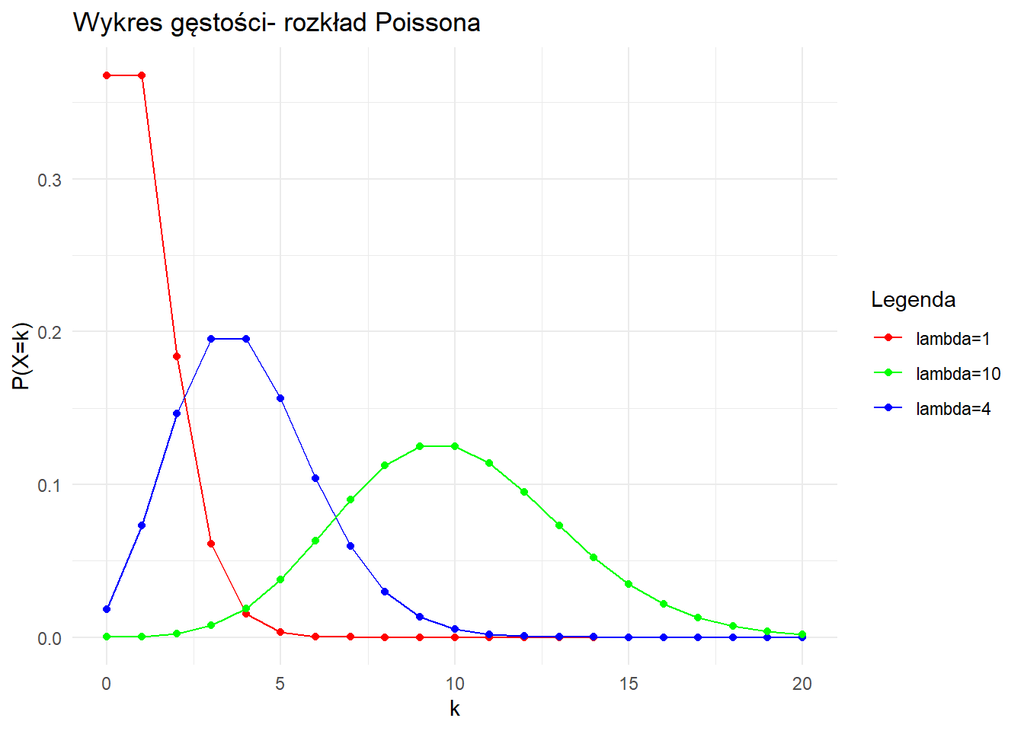

### Zastosowanie w medycynie

- Określa tempo przybycia pacjentów do szpitala Jest to krytyczna wartość w powszechnej sytuacji, gdzie liczba łóżek dostępnych dla pacjentów, aby pomieścić wszystkich nowych pacjentów.
- Przybliżone określenie przybywających pacjentów, aby określić poziom zatrudnienia do badań laboratoryjnych.

## Dodatni rozkład Poissona (Zero-truncated Poisson distribution)

### Opis rozkładu

Rozkład przyjmuje dodatnie liczby całkowite, jest to obcięty rozkład Poissona, który wyklucza 0. Znany jest też pod nazwami: warunkowy rozkład Poissona i dodatni rozkład Poissona. Zazwyczaj nie jesteśmy zainteresowani modelowaniem danych z tego rozkładu, ale jest on przydatny do generowania dodatnich zbiorów, gdzie nie jest pożądane występowanie wartości 0. Przykładem zmiennej z rozkładu jest na przykład zmienna liczby produktów w koszyku sklepowym przy linii kas w markecie.

Parametry:

- $k>0$- liczba wystąpień zdarzenia
- $\lambda$- dodatnia liczba rzeczywista, oczekiwana liczba zdarzeń w danych przedziale czasu

Funkcja masy prawdopodobieństwa $g(k,\lambda)$ ze standardowego rozkładu Poissona:

$$g(k,\lambda)=P(X=k|X>0)=\frac{f(k,\lambda)}{1-f(0,\lambda)}=\frac{\lambda^{k}}{(e^{\lambda}-1)k!}$$

$$\text{E(X)}=\frac{\lambda^{k}}{e^{\lambda}-1} \qquad
\text{Var}(X)=\frac{\lambda+\lambda^{2}}{1-e^{-\lambda}} +
\frac{\lambda^2}{(1-e^{-\lambda})^{2}}$$

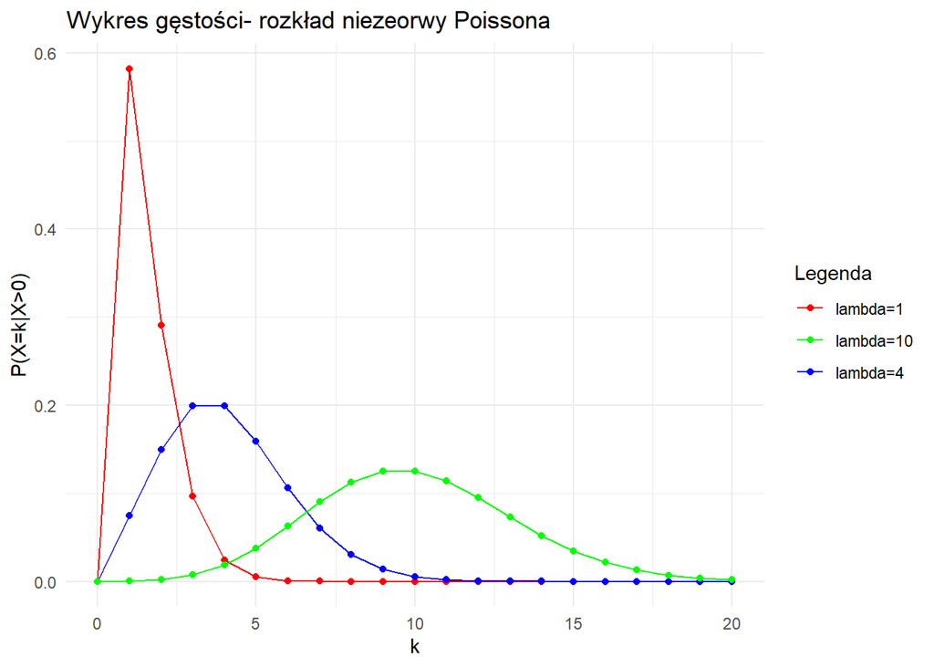

### Zastosowanie w medycynie

- w przypadku gdy wiemy, że zmiana np. w komórkach pojawi się do jakiegoś czasu, jesteśmy pewni, że istnieje małe prawdopodobieństwo, że pojawi się po wyznaczonym okresie (Yeh HW, n.d.).
- Badanie czynników ryzyka liczby naczyń ze zwężeniem w tętnicy wieńcowej, gdy wiemy, że pacjent ma jakąś dolegliwość np. zwężenie w tętnicy (Orooji et al. 2022).

## Rozkład jednostajny dyskretny

### Opis rozkładu

Rozkład przypisuje jednakowe prawdopodobieństwo do $n$ różnych liczb rzeczywistych $k_{1},\ldots, k_{n}$, natomiast inne liczby mają przypisane prawdopodobieństwo zero. Zakładamy też, że $k_{1},\ldots, k_{n}$ są liczbami całkowitymi z przedziału $[a,b]$.

Parametry:

- $n=a+b-1$- liczba elementów $k_{1},\ldots, k_{n}$
- $a,b$- krańce przedziału

Funkcja gęstości prawdopodobieństwa:

$$P(X=x)=\frac{1}{n} \quad a<k<b\\
\text{poza przedziałem [a,b] wynosi 0}$$

Dla zmiennej X o rozkładzie jednostajnym dyskretnym z parametrami k, a i b:
$$\text{E(X)}=\frac{a+b}{2} \qquad
\text{Var}(X)=\frac{n^{2}-1}{12}$$

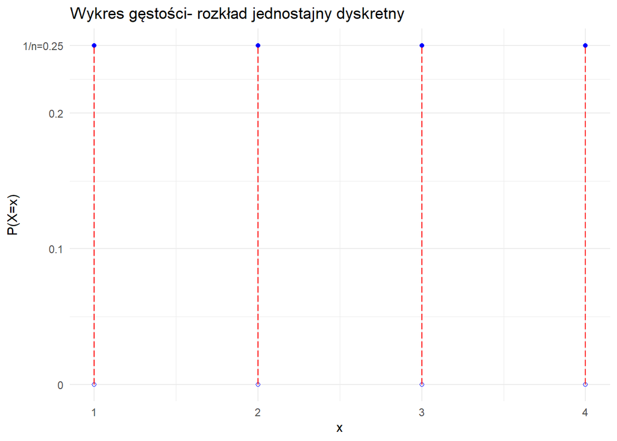

### Zastosowanie w medycynie

- W przypadku zdarzeń np. testów gdzie mamy policzalne, całkowite wyniki osiągane z równym prawdopodobieństwem, przedziałem jest ograniczona skala testu.

# Rozkłady ciągłe z simstudy

## Rozkład beta

### Opis rozkładu

Przyjmuje wartości od 0 do 1, został zastosowany do modelowania zachowania zmiennych losowych ograniczonych do przedziałów o skończonej długości. Rozkład jest sprzężonym rozkładem w statystyce Bayesowskiej do rozkładów między innymi: Bernoulliego i dwumianowego.

Parametry:

- $\alpha,\beta$- dodatnie parametry kształtu

Gęstość rozkładu:
$$X\sim\text{Beta}(\alpha,\beta)$$
$$f(x;\alpha,\beta)=
\frac{x^{\alpha-1}(1-x)^{\beta-1}}{\text{B}(\alpha,\beta)}\quad
\text{dla} \quad 0\leq x\leq1$$
$$\text{B}(\alpha,\beta)=\frac{\Gamma(\alpha)\Gamma(\beta)}{\Gamma(\alpha+\beta)}$$
$$\text{E(X)}=\frac{\alpha}{\alpha+\beta}
\qquad
\text{Var}(X)=\frac{\alpha\beta}{(\alpha+\beta)^{2}(\alpha+\beta+1)}$$

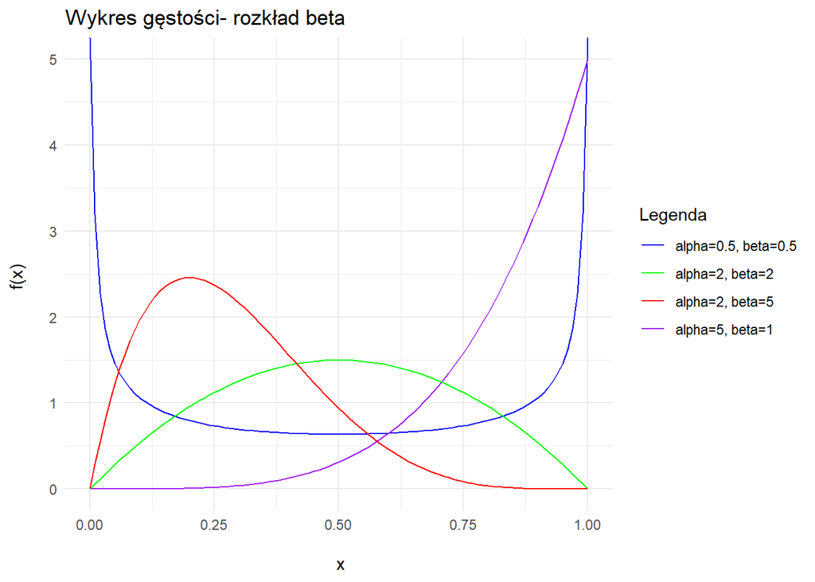

### Zastosowanie w medycynie

- Zastosowanie testów dopasowania rozkładu beta do stanowych wskaźników śmiertelności Covid-19 w Stanach, obliczonych przed oraz w trakcie prowadzenia kampanii szczepień (Santana-e-Silva 2022).

## Rozkład wykładniczy

### Rozkład do niego sprzężony: Gamma

### Opis rozkładu

Rozkład opisuje sytuację, w której oczekujemy n zjawisko całkowicie losowe, mogące zajść w dowolnej chwili $t\geq0$, rozkład posiada własność braku pamięci, co oznacza, że prawdopodobieństwo nie zmienia się gdy wiemy, że zdarzenie nie zaszło w przedziale czasowym [0,s]. Jest rozkładem prawdopodobieństwa, między zdarzeniami w punktowym procesie Poissona, czyli procesie, w którym zdarzenia występują w sposób ciągły ze stałą szybkością. Należy do rodziny rozkładów wykładniczych razem z np. rozkładem normalnym, dwumianowym, Poissona i Gamma.

Parametry:

- $\lambda$ - odwrotność parametru skali

Gęstość rozkładu:
$$X\sim\text{Exp}(\lambda)$$
$$f(x;\lambda)=\lambda e^{-\lambda x} \quad
\text{dla} \quad x\geq0$$
$$\text{E(X)}=\frac{1}{\lambda} \qquad
\text{Var}(X)=\frac{1}{\lambda^2}$$

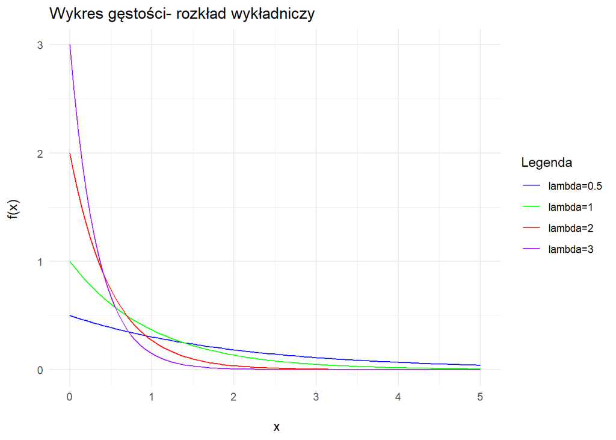

### Zastosowanie w medycynie

- W znalezionym artykule pojawiło się zastosowanie rozkładu do usuwania szumu z obrazów mózgu w celu ułatwienia diagnostyki, prawdopodobieństwo pojawienia się szumu było opisane rozkładem wykładniczym (Shrivastava et al. 2007).

## Rozkład Gamma

### Opis rozkładu

Rozkład jest uogólnioną wersją rozkładu wykładniczego, różnicą jest czas oczekiwania do kolejnego zdarzenia zamiast do pierwszego. Suma niezależnych $n$ zmiennych o rozkładzie Exp($\lambda$) ma rozkład Gammma(n,$\lambda$). Rozkład gamma jest rozkładem sprzężonym między innymi do rozkładów: wykładniczego i Poissona w statystyce Bayesowskiej [Conjugate prior](https://en.wikipedia.org/wiki/Conjugate_prior).

Parametry:

- $\alpha$ - parametr kształtu
- $\beta$- odwrotność parametru skali

Gęstość rozkładu:
$$X\sim\text{Gamma}(\alpha, \beta)$$
$$f(x;\alpha,\beta)=\frac{x^{\alpha-1}e^{-\beta x
}\beta^{\alpha}}{\Gamma(\alpha)} \quad \text{dla} \quad x>0, \quad
\alpha,\beta>0$$
$$\Gamma(z)=\int_{0}^{\infty}t^{z-1}e^{-t}dt$$
$$\text{E(X)}=\frac{\alpha}{\beta}
\qquad \text{Var}(X)=\frac{\alpha}{\beta^2}$$

[figure not shown]

### Zastosowanie w medycynie

- Używany do modelowania wskaźników raka, jest on podobny do rozkładu wykładniczego i można go wykorzystywać do podobnych zjawisk np. modelowania czasu remisji (Borlinhas et al. 2019).

## Rozkład normalny

### Rozkład do niego sprzężony: Normalny

### Opis rozkładu

Rozkład opisany parametrami $\mu$ oraz $\sigma^{2}$, bardzo często obserwowany w danych ze względu na jego charakter, gdy jakaś wielkość jest sumą lub średnią bardzo wielu drobnych losowych czynników to niezależnie od rozkładu czynników jej rozkład będzie zbliżony do normalnego.

Parametry:

- $\mu$ oraz $\sigma^2$

Funkcja gęstości dla rozkładu:
$$X\sim
N(\mu,\sigma^{2})$$
$$f(x)=\frac{1}{\sigma\sqrt{2\pi}}exp\left(\frac{-\left(x-\mu
\right)^2}{2\sigma^2}\right)$$

$$\text{E(X)}=\mu \qquad
\text{Var}(X)=\sigma^{2}$$

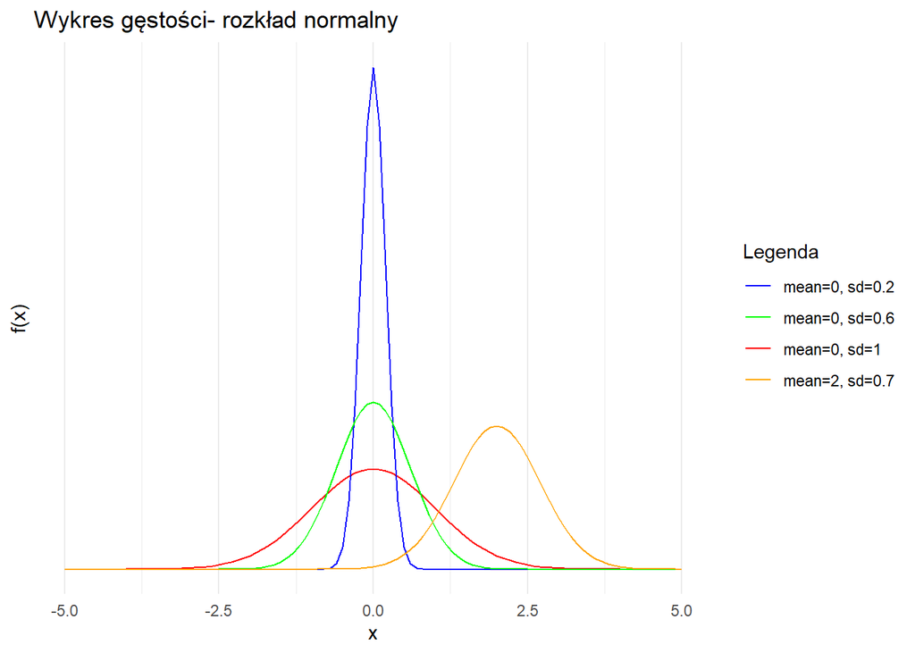

### Zastosowanie w medycynie

- Rozkład ma wiele zastosowań w medycynie, np. ciśnienie krwi ma rozkład normalny, możemy sprawdzić liczbę osób z danym ciśnieniem.
- Do oszacowania siły efektu dla danej grupy ludzi biorącej udział w badaniu.

## Rozkład jednostajny

### Rozkład do niego sprzężony: Pareto

### Opis rozkładu

Rozkład opisany parą parametrów a i b, krańcami wybranego przedziału, jego gęstość na przedziale od a do b jest różna od zera, ale poza nim równa 0.

Parametry:

- $a,b$- krańce przedziału

Funkcja gęstości prawdopodobieństwa:
$$X\sim\text{U}[a,b]$$
$$f(x)=\frac{1}{b-a} \quad a<x<b\\
\text{poza przedziałem [a,b] wynosi 0}$$
Dla zmiennej X o rozkładzie jednostajnym z parametrami a i b:
$$\text{E(X)}=\frac{a+b}{2} \qquad
\text{Var}(X)=\frac{(b-a)^{2}}{12}$$

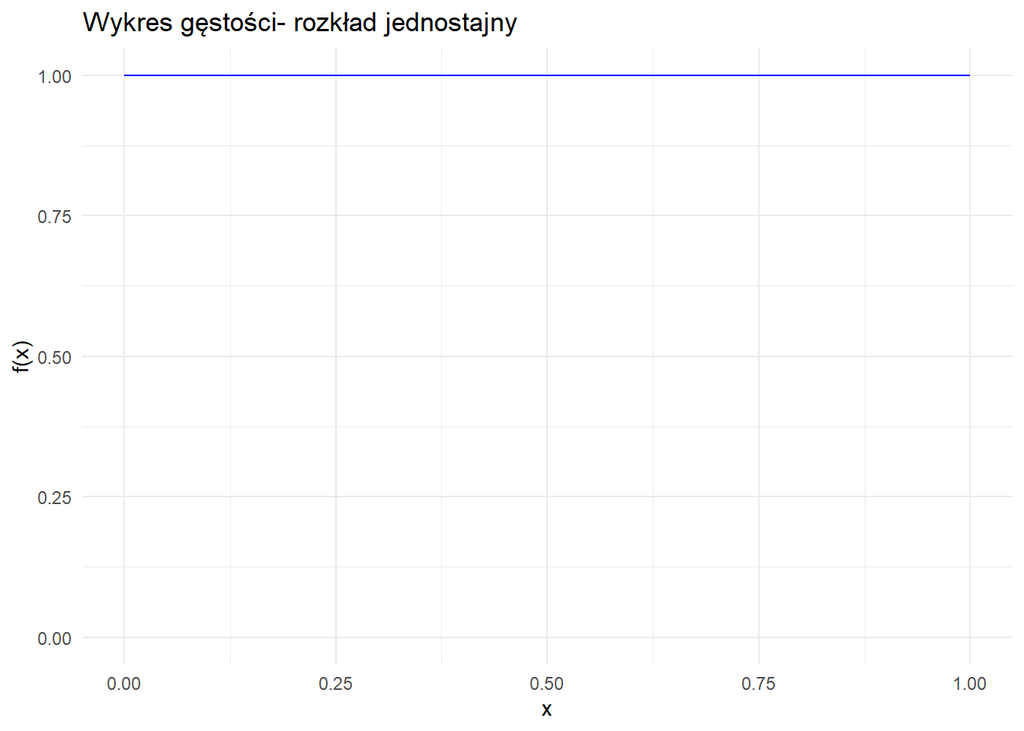

### Zastosowanie w medycynie

- Możemy wykorzystać rozkład do obliczenia niepewności całkowitej, przykładem sytuacji jest posiadanie informacji, że pojemność kolby w laboratorium jest podawana jako 1000 $\pm$ 4 ml, prawdopodobieństwo przyjęcia wartości w przedziale [996mL, 1004mL] jest takie samo (Coşkun and Oosterhuis 2020).
- Rozkład parametru ilości dni, po których nastąpi na przykład remisja choroby dla danej grupy, wykorzystane przy dokumencie symulacje FORMA.

# Inne rozkłady

## Rozkład Weibulla

### Opis rozkładu

Ciągły rozkład prawdopodobieństwa. Najczęściej rozkład jest stosowany do analizy przeżycia do modelowania sytuacji, gdy prawdopodobieństwo śmierci, awarii zmienia się w czasie/ W zależności od doboru parametrów, możemy otrzymać rozkład normalny (dla dużych k), lub wykładniczy.

Parametry:

- $\lambda$- parametr skali, możemy rozumieć jako czas po którym zginie $1-\frac{1}{e}\approx 63,2\%$
- $k$- parametr kształtu, określa zachowanie prawdopodobieństwa awarii w czasie

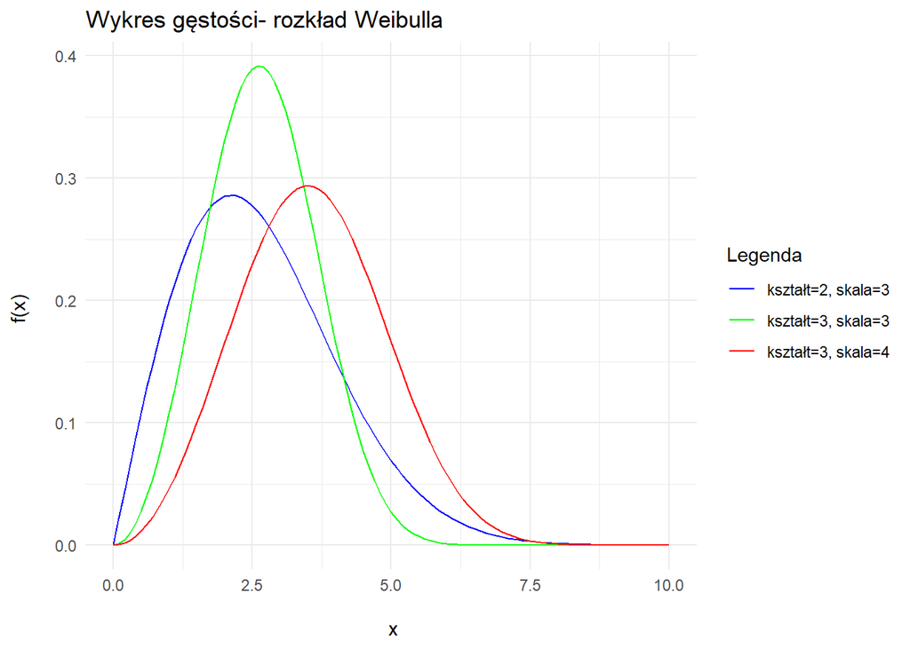

### Zastosowanie w medycynie

- Znaleziony artykuł obejmował zastosowanie funkcji rozkładu Weibulla jako alternatywy dla standardowej analizy wariancji przy małych próbkach, rezultatem było określenie większej czułości dla rozkładu [Use of the Weibull distribution for analysis of a clinical therapeutic study in rheumatoid arthritis](https://scholarlycommons.henryford.com/hfhmedjournal/vol24/iss3/7/).
- Zastosowany do badania wielkości próby z uwzględnieniem prawdopodobieństwa przerwania badania w symulacji, symulacja pozwoliła na oszacowanie parametrów rozkładu w oparciu o medianę czasu przeżycia i współczynnika zagrożenia (Jiang 2012).

## Rozkład Dirichleta

### Opis rozkładu

Rodzina ciągłych rozkładów prawdopodobieństwa wielu zmiennych określona wektorem $\alpha$ dodatnich liczb rzeczywistych. Jest uogólnieniem rozkładu beta w przestrzeni wielowymiarowej. Funkcja rozkładu zwraca przekonanie, że prawdopodobieństwo K możliwych zdarzeń losowych wynosi $x_{i}$ biorąc pod uwagę, że każde zdarzenie zostało zaobserwowane $\alpha_{i}-1$ razy.

### Zastosowanie w medycynie

- Stosowany przy symulowaniu danych gdzie rozróżniamy podział na kategorie np. rozłożenie pacjentów w ośrodkach, przy dokumencie FORMA.
- Wykorzystany przy symulowaniu statusów pacjentów, czyli np. wykluczenie, ukończenie lub pogorszenie, użyte w dokumencie UM Lublin.

# Bibliografia

Borlinhas, Filipa, Ricardo Loução, Raquel C. Conceição, and Hugo A. Ferreira. 2019. “Gamma Distribution Model in the Evaluation of Breast Cancer Through Diffusion-Weighted MRI: A Preliminary Study.” *Journal of Magnetic Resonance Imaging* 50 (1): 230–38. https://doi.org/https://doi.org/10.1002/jmri.26599.

Coşkun, Abdurrahman, and Wytze P. Oosterhuis. 2020. “Statistical Distributions Commonly Used in Measurement Uncertainty in Laboratory Medicine.” *Biochemia Medica* 30. https://www.ncbi.nlm.nih.gov/pmc/articles/PMC6999182/.

DeVeaux, Michelle, Michael J. Kane, and Daniel Zelterman. 2015. “A Stopped Negative Binomial Distribution.” arXiv. https://doi.org/10.48550/ARXIV.1508.01264.

Fink, Daniel. 1997. “A Compendium of Conjugate Priors.” *Technical Report.*, January.

Jiang, Ling AND Li, Zhiwei AND Wang. 2012. “A Practical Simulation Method to Calculate Sample Size of Group Sequential Trials for Time-to-Event Data Under Exponential and Weibull Distribution.” *PLOS ONE* 7 (9): 1–12. https://doi.org/10.1371/journal.pone.0044013.

Keith Goldfeld, Jacob Wujciak-Jens. n.d. “Simulating Study Data.” https://kgoldfeld.github.io/simstudy/articles/simstudy.html#binary.

Orooji, Arezoo, Toktam Sahranavard, Mohammad-Taghi Shakeri, Mohammad Tajfard, and Seyed Ehsan Saffari. 2022. “Application of the Truncated Zero-Inflated Double Poisson for Determining of the Effecting Factors on the Number of Coronary Artery Stenosis.” *Computational and Mathematical Methods in Medicine* 2022 (January): 1–7. https://doi.org/10.1155/2022/5353539.

Santana-e-Silva, Francisco AND Vasconcellos, José Jairo AND Cribari-Neto. 2022. “Beta Distribution Misspecification Tests with Application to Covid-19 Mortality Rates in the United States.” *PLOS ONE* 17 (9): 1–30. https://doi.org/10.1371/journal.pone.0274781.

Shrivastava, Amit, Monika Shinde, Shivanand Gornale, and Pratap Lawande. 2007. “An Approach-Effect of an Exponential Distribution on Different Medical Images,” January. https://www.researchgate.net/publication/255583156_An_Approach-Effect_of_an_Exponential_Distribution_on_different_medical_images/citation/download.

Yeh HW, Mukhopadhyay P, Gajewski B. n.d. “The Zero-Truncated Poisson with Right Censoring: An Application to Translational Breast Cancer Research.” https://www.ncbi.nlm.nih.gov/pmc/articles/PMC3487170/.